# behavior

Nessa análise de dados vamos ver dados referentes a padrões comportamentais das personalidades introvertida e extrovertida.

```python
#importar bibliotecas
import pandas as pd
import numpy as np
import matplotlib.pyplot as plt
import seaborn as sns
```

```python
#importando dataset
df = pd.read_csv('personality_dataset.csv')
print(f'As dimensões são: {df.shape}')
df.head()
```

```
As dimensões são: (2900, 8)
```

|  | Time_spent_Alone | Stage_fear | Social_event_attendance | Going_outside | Drained_after_socializing | Friends_circle_size | Post_frequency | Personality |
| --- | --- | --- | --- | --- | --- | --- | --- | --- |
| 0 | 4.0 | No | 4.0 | 6.0 | No | 13.0 | 5.0 | Extrovert |
| 1 | 9.0 | Yes | 0.0 | 0.0 | Yes | 0.0 | 3.0 | Introvert |
| 2 | 9.0 | Yes | 1.0 | 2.0 | Yes | 5.0 | 2.0 | Introvert |
| 3 | 0.0 | No | 6.0 | 7.0 | No | 14.0 | 8.0 | Extrovert |
| 4 | 3.0 | No | 9.0 | 4.0 | No | 8.0 | 5.0 | Extrovert |

Limpeza de dados

```python
#Verificar se há valores nulos
df.isnull().sum()
```

```
Time_spent_Alone             63
Stage_fear                   73
Social_event_attendance      62
Going_outside                66
Drained_after_socializing    52
Friends_circle_size          77
Post_frequency               65
Personality                   0
dtype: int64
```

```python
#tipos de dados
df.dtypes
```

```
Time_spent_Alone             float64
Stage_fear                    object
Social_event_attendance      float64
Going_outside                float64
Drained_after_socializing     object
Friends_circle_size          float64
Post_frequency               float64
Personality                   object
dtype: object
```

```python
#Coluna Time_spent_Alone
print(df['Time_spent_Alone'].unique())
print(df['Time_spent_Alone'].value_counts())
```

```
[ 4.  9.  0.  3.  1.  2. 10.  6.  5.  8. nan  7. 11.]
Time_spent_Alone
0.0     369
2.0     357
3.0     353
1.0     326
9.0     206
10.0    196
4.0     190
7.0     190
8.0     180
5.0     180
6.0     150
11.0    140
Name: count, dtype: int64
```

O método KNN será utilizado para corrigir os dados faltantes. Já que as duas personalidade possuem diferenças de comportamento que assemelham em grupo, serão criados dois atributos, introvert e extrovert. Assim as médias poderão ter mais exatidão.

```python
from sklearn.impute import KNNImputer
from sklearn.preprocessing import MinMaxScaler

def aplicarKNN(dfSubset, colNum, K=5):
    dfSubset = dfSubset.copy()

    # Verificar se colunas têm pelo menos um valor não nulo
    colunas_validas = [col for col in colNum if dfSubset[col].notna().sum() > 0]

    if not colunas_validas:
        print("Nenhuma coluna tem dados suficientes para aplicar KNN.")
        return dfSubset

    # Selecionar as colunas válidas
    dfNum = dfSubset[colunas_validas]

    # Escalar os dados
    escala = MinMaxScaler()
    dfEscala = pd.DataFrame(
        escala.fit_transform(dfNum),
        columns=colunas_validas,
        index=dfNum.index
    )

    # Aplicar KNNImputer
    imputar = KNNImputer(n_neighbors=K)
    dfImputado = pd.DataFrame(
        imputar.fit_transform(dfEscala),
        columns=colunas_validas,
        index=dfNum.index
    )

    # Reverter a escala
    dfOriginal = pd.DataFrame(
        escala.inverse_transform(dfImputado),
        columns=colunas_validas,
        index=dfNum.index
    )

    # Arrendondados os valores imputados
    dfOriginal = dfOriginal.round(0)

    # Substituir no DataFrame original
    dfSubset[colunas_validas] = dfOriginal

    return dfSubset
```

```python
# Definir as colunas numéricas
colunasNumericas = df.select_dtypes(include=['float64']).columns

# Separar os grupos
introvert = df[df['Personality'] == 'Introvert'].copy()
extrovert = df[df['Personality'] == 'Extrovert'].copy()

# Aplicar a função nos dois grupos
introvertLimpo = aplicarKNN(introvert, colunasNumericas, K=5)
extrovertLimpo = aplicarKNN(extrovert, colunasNumericas, K=5)

# Juntar novamente
dfFinal = pd.concat([introvertLimpo, extrovertLimpo]).sort_index()

# Verificar NaNs
print(dfFinal.isna().sum())
```

```
Time_spent_Alone              0
Stage_fear                   73
Social_event_attendance       0
Going_outside                 0
Drained_after_socializing    52
Friends_circle_size           0
Post_frequency                0
Personality                   0
dtype: int64
```

Quantos aos dados categóricos, a opção é utilizar a moda de cada um dos atributos de personalidade separadamente.

```python
#Colunas categóricas para tratar
colunasCategoricas = df[['Drained_after_socializing','Stage_fear']]

introverts = dfFinal[dfFinal['Personality'] == 'Introvert'].copy()
extroverts = dfFinal[dfFinal['Personality'] == 'Extrovert'].copy()

def modaCategorica(dfGrupo,colunas):
    for col in colunas:
        moda = dfGrupo[col].mode(dropna=True)[0]
        dfGrupo[col] = dfGrupo[col].fillna(moda)
    return dfGrupo
```

```python
#Aplicar a fórmula aos atributos
introverts = modaCategorica(introverts,colunasCategoricas)
extroverts = modaCategorica(extroverts,colunasCategoricas)

#Concatenar atributos
dfFinal = pd.concat([introverts,extroverts]).sort_index()

dfFinal.isna().sum()
```

```
Time_spent_Alone             0
Stage_fear                   0
Social_event_attendance      0
Going_outside                0
Drained_after_socializing    0
Friends_circle_size          0
Post_frequency               0
Personality                  0
dtype: int64
```

Visualização gráfica dos dados

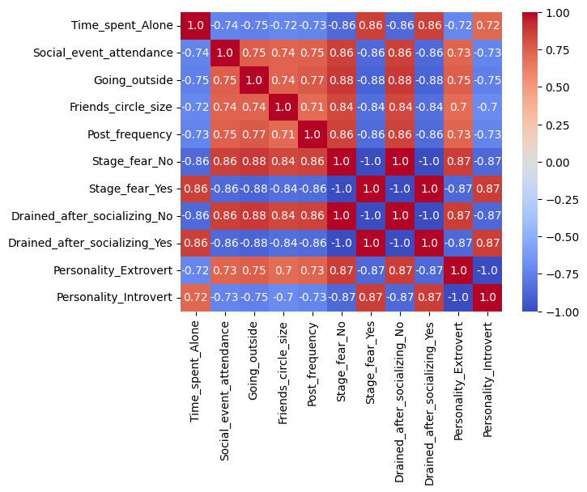

```python
#Criar um gráfico de correlação
dfCorre = pd.get_dummies(dfFinal,columns=['Stage_fear','Drained_after_socializing','Personality'])
corre = dfCorre.corr()
sns.heatmap(data=corre,annot=True,cmap='coolwarm',fmt='0.2')
plt.show()
```

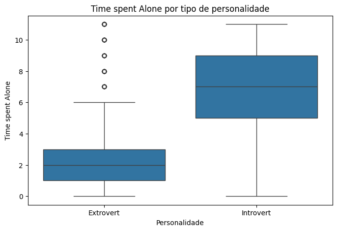

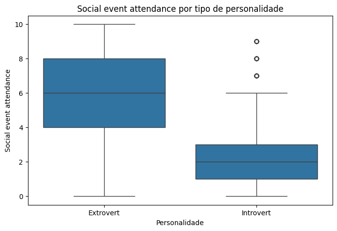

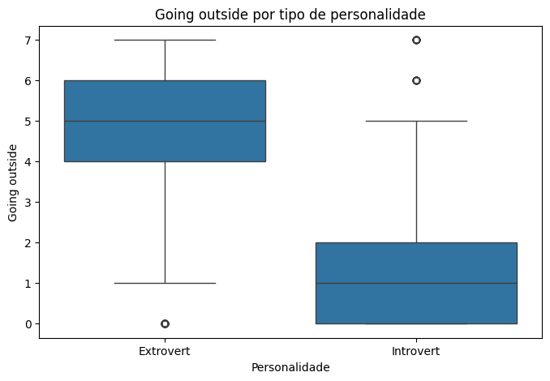

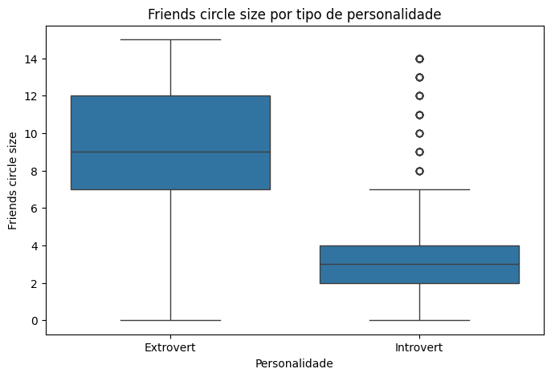

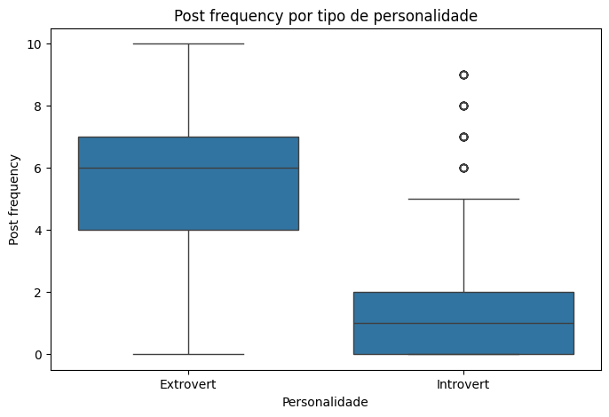

```python
#boxplot
variaveis = dfFinal.select_dtypes('float64')
for var in variaveis:
    plt.figure(figsize=(8,5))
    sns.boxplot(data=dfFinal, x='Personality',y=var)
    plt.title(f'{var.replace("_", " ")} por tipo de personalidade')
    plt.xlabel('Personalidade')
    plt.ylabel(var.replace("_", " "))
    plt.show()
```

```python
from sklearn.preprocessing import StandardScaler

# Selecionar colunas numéricas
X = dfFinal.select_dtypes(include='number')

# Padronizar os dados (média = 0, desvio = 1)
scaler = StandardScaler()
X_scaled = scaler.fit_transform(X)

from sklearn.cluster import KMeans

kmeans = KMeans(n_clusters=2, random_state=42)
clusters = kmeans.fit_predict(X_scaled)

# Adicionar o rótulo de cluster ao DataFrame
dfFinal['Cluster'] = clusters
```

```python
# Tabela cruzada: Cluster vs Personalidade
pd.crosstab(dfFinal['Cluster'], dfFinal['Personality'])
```

| Personality Cluster | Extrovert | Introvert |
| --- | --- | --- |
| 0 | 1380 | 79 |
| 1 | 111 | 1330 |

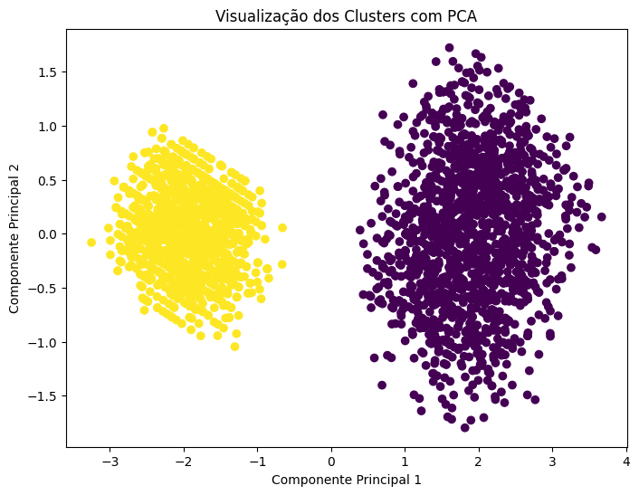

```python
from sklearn.decomposition import PCA

# Reduzir para 2D
pca = PCA(n_components=2)
X_pca = pca.fit_transform(X_scaled)

# Plotar os clusters
plt.figure(figsize=(8, 6))
plt.scatter(X_pca[:, 0], X_pca[:, 1], c=clusters, cmap='viridis')
plt.title('Visualização dos Clusters com PCA')
plt.xlabel('Componente Principal 1')
plt.ylabel('Componente Principal 2')
plt.show()
```

```python
#Calcular a acuracidade
from sklearn.metrics import accuracy_score

#Transformar os rótulos para binário
trueLabels = dfFinal['Personality'].map({'Extrovert':0, 'Introvert':1}).values
predictLabel = dfFinal['Cluster'].values

#Compararação direta
acc1 = accuracy_score(trueLabels,predictLabel)

#Invertendo clusters e comparando novamente
acc2 = accuracy_score(trueLabels, 1 - predictLabel)

#O maior valor das comparações
accuracy = max(acc1,acc2)

print(f'Acurácia dos Kmeans em relação as personalidade: {accuracy:.2f}')
```

```
Acurácia dos Kmeans em relação as personalidade: 0.93
```

As diferenças entre os padrões dos grupos podem ser observadas pelos boxplots de cada coluna numérica. A aplicação do algoritmo KMeans identificou dois grupos distintos, obtendo uma acurácia de 93% em relação aos rótulos originais de personalidade. Isso demonstra que os dados comportamentais contêm padrões suficientes para distinguir introvertidos de extrovertidos, mesmo sem supervisão explícita.

Vamos tentar prever a personalidade através dos padrões de comportamento com classificações supervisionadas.

```python
from sklearn.model_selection import train_test_split

#Preparar os dados

#Selecionar os dados numéricos
DN = dfFinal.select_dtypes('float64')

#Organizar as personalidades em binário
DP = dfFinal['Personality'].map({'Extrovert':0,'Introvert':1})
```

```python
#Dividir em treino/teste

DNTrain, DNTest, DPTrain, DPTest = train_test_split(DN,DP,test_size=0.3,random_state=42)
```

```python
#Regressão logística

from sklearn.linear_model import LogisticRegression
logModel = LogisticRegression()
logModel.fit(DNTrain, DPTrain)
```

```
LogisticRegression()
```

```python
#Árvore de Decisão
from sklearn.tree import DecisionTreeClassifier

TreeModel = DecisionTreeClassifier()
TreeModel.fit(DNTrain,DPTrain)
```

```
DecisionTreeClassifier()
```

```python
#Random Forest
from sklearn.ensemble import RandomForestClassifier
ForeModel = RandomForestClassifier()
ForeModel.fit(DNTrain,DPTrain)
```

```
RandomForestClassifier()
```

```python
#Avaliar modelos
from sklearn.metrics import classification_report

#Previsões
DPredLog = logModel.predict(DNTest)
DPredTree = TreeModel.predict(DNTest)
DPredFore = ForeModel.predict(DNTest)

#Avaliação
print('Regressão Logística')
print(classification_report(DPTest,DPredLog))

print('Árvore de Decisão')
print(classification_report(DPTest,DPredTree))

print('Random Forest')
print(classification_report(DPTest,DPredFore))
```

```
Regressão Logística
              precision    recall  f1-score   support

           0       0.94      0.92      0.93       463
           1       0.91      0.93      0.92       407

    accuracy                           0.93       870
   macro avg       0.93      0.93      0.93       870
weighted avg       0.93      0.93      0.93       870

Árvore de Decisão
              precision    recall  f1-score   support

           0       0.87      0.86      0.87       463
           1       0.84      0.85      0.85       407

    accuracy                           0.86       870
   macro avg       0.86      0.86      0.86       870
weighted avg       0.86      0.86      0.86       870

Random Forest
              precision    recall  f1-score   support

           0       0.92      0.92      0.92       463
           1       0.90      0.90      0.90       407

    accuracy                           0.91       870
   macro avg       0.91      0.91      0.91       870
weighted avg       0.91      0.91      0.91       870
```

Vamos ver graficamente os modelos

```python
#Diminuir as dimensões para 2
pca = PCA(n_components=2)
DNPca = pca.fit_transform(DN)
```

```python
#Treinar modelo com PCA
DNPcaTrain, DNPcaTest, DPTrain,DPtest = train_test_split(DNPca, DP, test_size=0.2, random_state= 42)
```

```python
#Treinar modelos com PCA
logModel = LogisticRegression().fit(DNPcaTrain, DPTrain)
TreeModel = DecisionTreeClassifier(max_depth=4,random_state=42).fit(DNPcaTrain,DPTrain)
ForeModel = RandomForestClassifier(n_estimators=100, random_state=42).fit(DNPcaTrain, DPTrain)
```

```python
#Função para visualizar os modelos

def plotDecisionBoundary(model,x,y,title):
    h = 0.01
    xMin, xMax = x[:, 0].min() - .1, x[:, 0].max() + .1
    yMin, yMax = x[:, 0].min() - .1, x[:, 0].max() + .1
    xx, yy = np.meshgrid(np.arange(xMin,xMax, h),
                         np.arange(yMin,yMax, h))

    z = model.predict(np.c_[xx.ravel(), yy.ravel()])
    z = z.reshape(xx.shape)

    plt.figure(figsize=(10,8))
    plt.contour(xx,yy,z,alpha=0.3,cmap='coolwarm')
    plt.scatter(x[:, 0], x[:,1], c=y,cmap='coolwarm', edgecolors='k')
    plt.title(title)
    plt.xlabel('PCA 1')
    plt.ylabel('PCA 2')
    plt.tight_layout()
    plt.show()
```

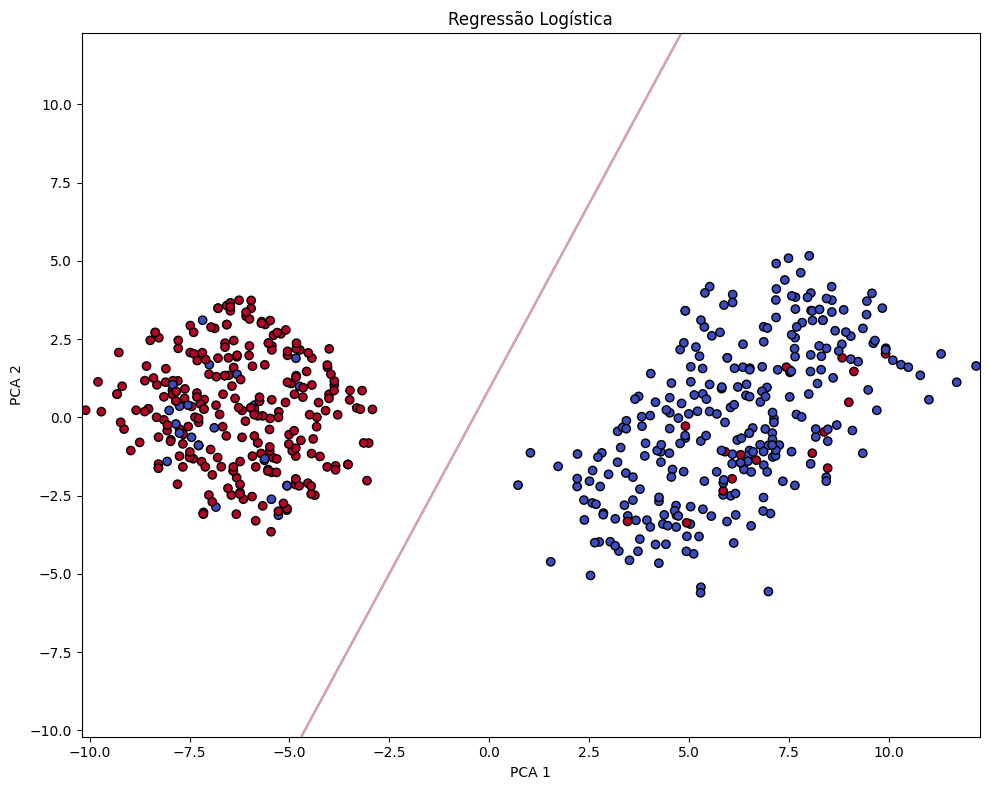

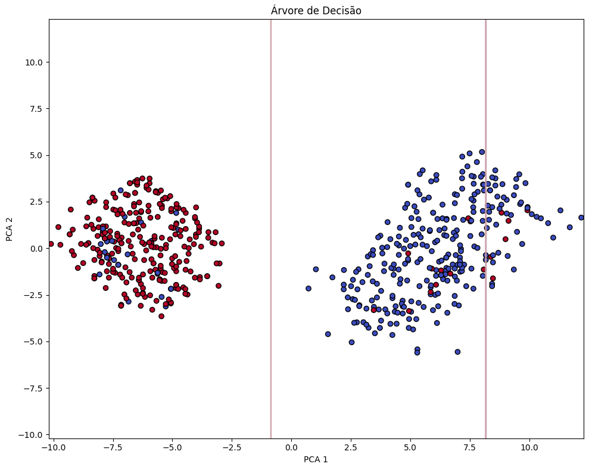

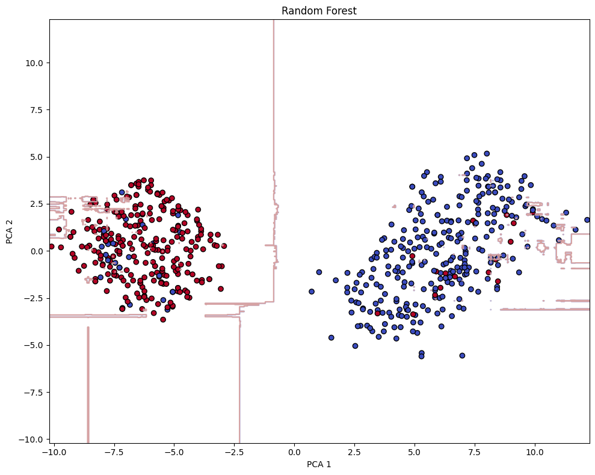

```python
#Visualizar modelos
plotDecisionBoundary(logModel, DNPcaTest, DPtest,"Regressão Logística")
plotDecisionBoundary(TreeModel, DNPcaTest, DPtest,"Árvore de Decisão")
plotDecisionBoundary(ForeModel, DNPcaTest, DPtest,"Random Forest")
```

Entre os três modelos supervisionados, a regressão logística foi a que teve maior acurácia, sendo de 93%. Isso significa que ela é a mais precisa para os dados. Os demais modelos também obtiveram um bom resultado, sendo a Árvore de decisão com 86% e Random Forest 91% de acurácia, mostrando que é possível alcançar padrões de comportamento dos dados através dos dados supervisionados.